# Chapter 3 Exercise Solutions

Keith McNulty

```r
library(rethinking)
set.seed(100)

# function to grid approximate posterior of globe tossing example
globe_posterior_grid <- function(water = 6, all = 9, n = 1000, grid.size = 1e4, priorfn = function(x) 1) {
  p_grid <- seq(from = 0, to = 1, length.out = n)
  prior = priorfn(p_grid)
  likelihood <- dbinom(water, size = all, prob = p_grid) #binomial likelihood
  posterior <- likelihood * prior
  posterior <- posterior/sum(posterior)
  samples <- sample(p_grid, prob = posterior, size = grid.size, replace = TRUE)
}

samples <- globe_posterior_grid()
```

## ‘Easy’ exercises

### 3E1

```r
mean(samples < 0.2)
```

```
## [1] 4e-04
```

### 3E2

```r
mean(samples > 0.8)
```

```
## [1] 0.1116
```

### 3E3

```r
sum(samples > 0.2 & samples < 0.8)/sum(samples <= 1)
```

```
## [1] 0.888
```

### 3E4

```r
quantile(samples, 0.2)
```

```
##       20%
## 0.5185185
```

### 3E5

```r
quantile(samples, 0.8)
```

```
##       80%
## 0.7557558
```

### 3E6

```r
rethinking::HPDI(samples, prob = 0.66)
```

```
##     |0.66     0.66|
## 0.5085085 0.7737738
```

### 3E7

```r
rethinking::PI(samples, prob = 0.66)
```

```
##       17%       83%
## 0.5025025 0.7697698
```

## ‘Medium’ Exercises

### 3M1

```r
samples_new <- globe_posterior_grid(water = 8, all = 15)
```

### 3M2

```r
rethinking::HPDI(samples_new, prob = 0.9)
```

```
##      |0.9      0.9|
## 0.3293293 0.7167167
```

### 3M3

```r
posterior_check1 <- rbinom(1e4, size = 15, prob = samples)
mean(posterior_check1 == 8)
```

```
## [1] 0.1102
```

### 3M4

```r
posterior_check2 <- rbinom(1e4, size = 9, prob = samples)
mean(posterior_check2 == 6)
```

```
## [1] 0.1998
```

### 3M5

```r
samples_newprior <- globe_posterior_grid(prior = function(x) ifelse(x < 0.5, 0, 1))

# this removes all probability that p < 0.5
rethinking::HPDI(samples_newprior, prob = 0.9)
```

```
##      |0.9      0.9|
## 0.5005005 0.8248248
```

```r
# zero probability that p < 0.2, consistent with new prior
sum(samples_newprior < 0.2)/sum(samples_newprior <= 1)
```

```
## [1] 0
```

```r
# 6 from 9 case - new prior narrows range of likely values for p
sum(samples_newprior < 0.8)/sum(samples_newprior <= 1)
```

```
## [1] 0.8538
```

```r
sum(samples_newprior > 0.2 & samples_newprior < 0.8)/sum(samples_newprior <= 1)
```

```
## [1] 0.8538
```

```r
quantile(samples_newprior, 0.2)
```

```
##       20%
## 0.5835836
```

```r
quantile(samples_newprior, 0.8)
```

```
##       80%
## 0.7767768
```

```r
rethinking::HPDI(samples_newprior, prob = 0.66)
```

```
##     |0.66     0.66|
## 0.5475475 0.7607608
```

```r
rethinking::PI(samples_newprior, prob = 0.66)
```

```
##       17%       83%
## 0.5715716 0.7897898
```

It appears that the prior aids in narrowing the likelihood range for the true value of p and ensures that the known impossibility range has zero likelihood ($p < 0.5$).

```r
samples_new_newprior <- globe_posterior_grid(water = 8, all = 15, prior = function(x) ifelse(x < 0.5, 0, 1))

rethinking::HPDI(samples_new_newprior, prob = 0.9)
```

```
##      |0.9      0.9|
## 0.5005005 0.7117117
```

```r
posterior_check1_newprior <- rbinom(1e4, size = 15, prob = samples_new_newprior)
sum(posterior_check1_newprior == 8)/sum(posterior_check1_newprior <= 15)
```

```
## [1] 0.1566
```

```r
posterior_check2_newprior <- rbinom(1e4, size = 9, prob = samples_new_newprior)
sum(posterior_check2_newprior == 6)/sum(posterior_check2_newprior <= 9)
```

```
## [1] 0.223
```

Again we see a narrowing of the likelihood range, and because both possibilities (8/15 and 6/8) are p > 0.5, we see increases in their likelihood because our new prior has provided additional information.

# 3M6

I am extending this question to test the effect of different levels of prior knowledge on posterior certainty.

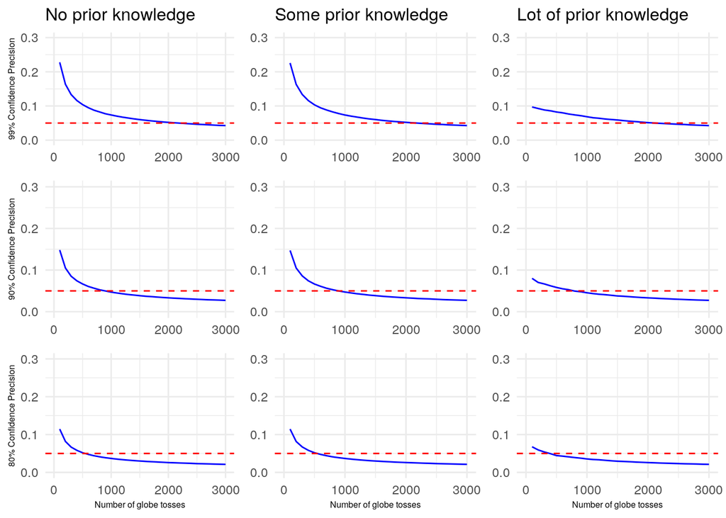

```r
library(dplyr)
library(ggplot2)

# write function to sample based on an observation

single_obs <- function(globe_tosses, priorfn = function(x) {1}, intprob = 0.99) {
  # get an observation based on real globe
  obs <- rbinom(1, globe_tosses, prob = 0.71)

  # calculate posterior
  p_grid <- seq(from = 0, to = 1, length.out = 1000)
  prior <- priorfn(p_grid)
  likelihood <- dbinom(obs, size = globe_tosses, prob = p_grid)
  posterior <- likelihood * prior
  posterior <- posterior / sum(posterior)

  # generate sample and calculate interval size
  sample <- sample(p_grid, prob = posterior, size = 1e4, replace = TRUE)
  interval <- rethinking::PI(sample, prob = intprob)
  interval[2] - interval[1]
}

# run this an arbitrary number of times and produce a dataframe row
run_sim <- function(globe_tosses, priorfn = function(x) {1}, times = 100, intprob = 0.99) {
  simdata <- data.frame()
  for (i in 1:times) {
    simdata[1,i] <- single_obs(globe_tosses, priorfn, intprob)
  }
  colnames(simdata) <- paste0("sim", 1:times)
  simdata
}

# create a set of globe_tosses values in a dataframe
toss_data <- data.frame(
  tosses = seq(100, 3000, by = 100)
)

# 99% certainty
# mutate observation data for uniform prior and calculate average interval width
toss_data_uniform <- toss_data %>%
  dplyr::rowwise() %>%
  dplyr::mutate(run_sim(tosses),
                ave_int_unif = mean(c_across(starts_with("sim")))) %>%
  dplyr::select(tosses, ave_int_unif)

# mutate observation data for step1 prior and calculate average interval width
toss_data_step1 <- toss_data %>%
  dplyr::rowwise() %>%
  dplyr::mutate(run_sim(tosses, priorfn = function(x) ifelse(x < 0.5, 0, 1)),
                ave_int_step1 = mean(c_across(starts_with("sim")))) %>%
  dplyr::select(tosses, ave_int_step1)

# mutate observation data for step2 prior and calculate average interval width
toss_data_step2 <- toss_data %>%
  dplyr::rowwise() %>%
  dplyr::mutate(run_sim(tosses, priorfn = function(x) ifelse(x > 0.65 & x < 0.75, 1, 0)),
                ave_int_step2 = mean(c_across(starts_with("sim")))) %>%
  dplyr::select(tosses, ave_int_step2)

# graph curves

plot99_unif <- ggplot(data = toss_data_uniform,
                    aes(x = tosses, y = ave_int_unif)) +
  xlim(0, 3000) +
  ylim(0, 0.3) +
  geom_line(color = "blue") +
  geom_hline(yintercept = 0.05, color = "red", linetype = "dashed") +
  labs(y = "99% Confidence Precision",
       title = "No prior knowledge") +
  theme_minimal() +
  theme(axis.title.y = element_text(size = 6),
        axis.title.x = element_blank(),
        title = element_text(size = 10))

plot99_step1 <- ggplot(data = toss_data_step1,
                    aes(x = tosses, y = ave_int_step1)) +
  xlim(0, 3000) +
  ylim(0, 0.3) +
  geom_line(color = "blue") +
  geom_hline(yintercept = 0.05, color = "red", linetype = "dashed") +
  labs(title = "Some prior knowledge") +
  theme_minimal() +
  theme(title = element_text(size = 10),
        axis.title.x = element_blank(),
        axis.title.y = element_blank())

plot99_step2 <- ggplot(data = toss_data_step2,
                    aes(x = tosses, y = ave_int_step2)) +
  xlim(0, 3000) +
  ylim(0, 0.3) +
  geom_line(color = "blue") +
  geom_hline(yintercept = 0.05, color = "red", linetype = "dashed") +
  labs(title = "Lot of prior knowledge") +
  theme_minimal() +
  theme(title = element_text(size = 10),
        axis.title.x = element_blank(),
        axis.title.y = element_blank())

# 90% certainty
# mutate observation data for uniform prior and calculate average interval width
toss_data_uniform <- toss_data %>%
  dplyr::rowwise() %>%
  dplyr::mutate(run_sim(tosses, intprob = 0.9),
                ave_int_unif = mean(c_across(starts_with("sim")))) %>%
  dplyr::select(tosses, ave_int_unif)

# mutate observation data for step1 prior and calculate average interval width
toss_data_step1 <- toss_data %>%
  dplyr::rowwise() %>%
  dplyr::mutate(run_sim(tosses, priorfn = function(x) ifelse(x < 0.5, 0, 1), intprob = 0.9),
                ave_int_step1 = mean(c_across(starts_with("sim")))) %>%
  dplyr::select(tosses, ave_int_step1)

# mutate observation data for step2 prior and calculate average interval width
toss_data_step2 <- toss_data %>%
  dplyr::rowwise() %>%
  dplyr::mutate(run_sim(tosses, priorfn = function(x) ifelse(x > 0.65 & x < 0.75, 1, 0), intprob = 0.9),
                ave_int_step2 = mean(c_across(starts_with("sim")))) %>%
  dplyr::select(tosses, ave_int_step2)

# graph curves

plot90_unif <- ggplot(data = toss_data_uniform,
                    aes(x = tosses, y = ave_int_unif)) +
  xlim(0, 3000) +
  ylim(0, 0.3) +
  geom_line(color = "blue") +
  geom_hline(yintercept = 0.05, color = "red", linetype = "dashed") +
  labs(y = "90% Confidence Precision") +
  theme_minimal() +
  theme(title = element_blank(),
        axis.title.x = element_blank(),
        axis.title.y = element_text(size = 6))

plot90_step1 <- ggplot(data = toss_data_step1,
                    aes(x = tosses, y = ave_int_step1)) +
  xlim(0, 3000) +
  ylim(0, 0.3) +
  geom_line(color = "blue") +
  geom_hline(yintercept = 0.05, color = "red", linetype = "dashed") +
  theme_minimal() +
  theme(title = element_blank(),
        axis.title.x = element_blank(),
        axis.title.y = element_blank())

plot90_step2 <- ggplot(data = toss_data_step2,
                    aes(x = tosses, y = ave_int_step2)) +
  xlim(0, 3000) +
  ylim(0, 0.3) +
  geom_line(color = "blue") +
  geom_hline(yintercept = 0.05, color = "red", linetype = "dashed") +
  theme_minimal() +
  theme(title = element_blank(),
      axis.title.x = element_blank(),
      axis.title.y = element_blank())

# 80% certainty
# mutate observation data for uniform prior and calculate average interval width
toss_data_uniform <- toss_data %>%
  dplyr::rowwise() %>%
  dplyr::mutate(run_sim(tosses, intprob = 0.8),
                ave_int_unif = mean(c_across(starts_with("sim")))) %>%
  dplyr::select(tosses, ave_int_unif)

# mutate observation data for step1 prior and calculate average interval width
toss_data_step1 <- toss_data %>%
  dplyr::rowwise() %>%
  dplyr::mutate(run_sim(tosses, priorfn = function(x) ifelse(x < 0.5, 0, 1), intprob = 0.8),
                ave_int_step1 = mean(c_across(starts_with("sim")))) %>%
  dplyr::select(tosses, ave_int_step1)

# mutate observation data for step2 prior and calculate average interval width
toss_data_step2 <- toss_data %>%
  dplyr::rowwise() %>%
  dplyr::mutate(run_sim(tosses, priorfn = function(x) ifelse(x > 0.65 & x < 0.75, 1, 0), intprob = 0.8),
                ave_int_step2 = mean(c_across(starts_with("sim")))) %>%
  dplyr::select(tosses, ave_int_step2)

# graph curves

plot80_unif <- ggplot(data = toss_data_uniform,
                    aes(x = tosses, y = ave_int_unif)) +
  xlim(0, 3000) +
  ylim(0, 0.3) +
  geom_line(color = "blue") +
  geom_hline(yintercept = 0.05, color = "red", linetype = "dashed") +
  labs(x = "Number of globe tosses",
       y = "80% Confidence Precision") +
  theme_minimal() +
  theme(title = element_blank(),
        axis.title.x = element_text(size = 6),
        axis.title.y = element_text(size = 6))

plot80_step1 <- ggplot(data = toss_data_step1,
                    aes(x = tosses, y = ave_int_step1)) +
  xlim(0, 3000) +
  ylim(0, 0.3) +
  geom_line(color = "blue") +
  geom_hline(yintercept = 0.05, color = "red", linetype = "dashed") +
  labs(x = "Number of globe tosses") +
  theme_minimal() +
  theme(title = element_blank(),
        axis.title.x = element_text(size = 6),
        axis.title.y = element_blank())

plot80_step2 <- ggplot(data = toss_data_step2,
                    aes(x = tosses, y = ave_int_step2)) +
  xlim(0, 3000) +
  ylim(0, 0.3) +
  geom_line(color = "blue") +
  geom_hline(yintercept = 0.05, color = "red", linetype = "dashed") +
  labs(x = "Number of globe tosses") +
  theme_minimal() +
  theme(title = element_blank(),
      axis.title.x = element_text(size = 6),
      axis.title.y = element_blank())


plot <- gridExtra::grid.arrange(plot99_unif, plot99_step1, plot99_step2,
                                plot90_unif, plot90_step1, plot90_step2,
                                plot80_unif, plot80_step1, plot80_step2,
                                nrow = 3, ncol = 3)
```

We note that the prior has minimal effect on the number of observations needed except when we demand a lower level of certainty.

## ‘Hard’ Exercises

```r
data(homeworkch3)
```

### 3H1

```r
birth_boys <- sum(birth1 == 1) + sum(birth2 == 1)
births <- length(birth1) + length(birth2)

p_grid <- seq(from = 0, to = 1, length.out = 1000)
prior <- rep(1, 1000)
likelihood <- dbinom(birth_boys, size = births, prob = p_grid)
posterior <- likelihood*prior/sum(likelihood*prior)
p_grid[which.max(posterior)]
```

```
## [1] 0.5545546
```

### 3H2

```r
samples <- sample(p_grid, size = 1e4, prob = posterior, replace = TRUE)

intervals <- c(0.5, 0.89, 0.97)

rethinking::HPDI(samples, prob = intervals)
```

```
##     |0.97     |0.89      |0.5      0.5|     0.89|     0.97|
## 0.4744745 0.4964965 0.5305305 0.5765766 0.6076076 0.6256256
```

### 3H3

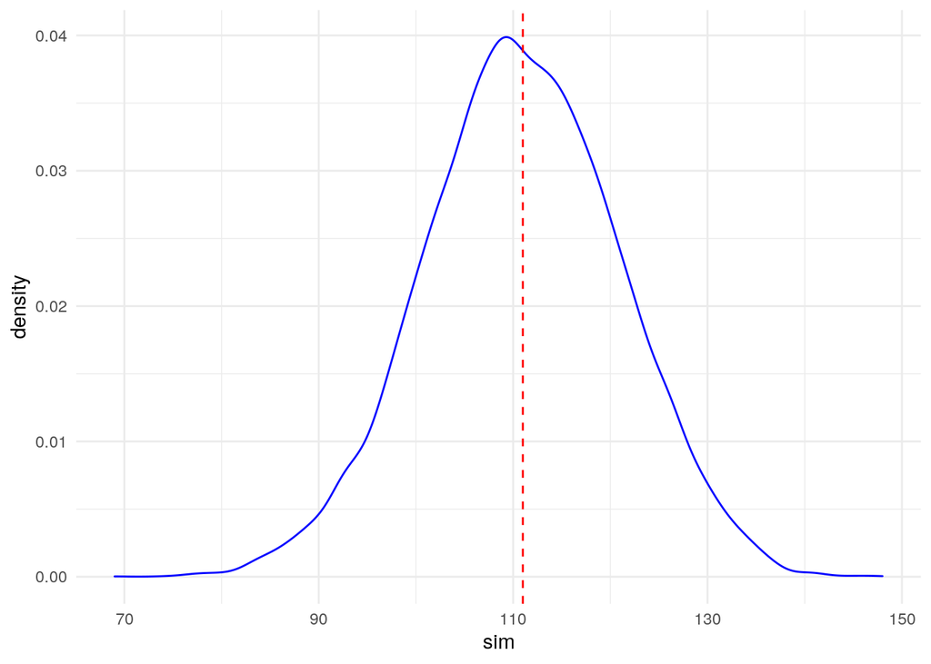

```r
sim <- rbinom(1e4, 200, prob = samples)

ggplot() +
  geom_density(aes(x = sim), color = "blue") +
  geom_vline(xintercept = birth_boys, color = "red", linetype = "dashed") +
  theme_minimal()
```

### 3H4

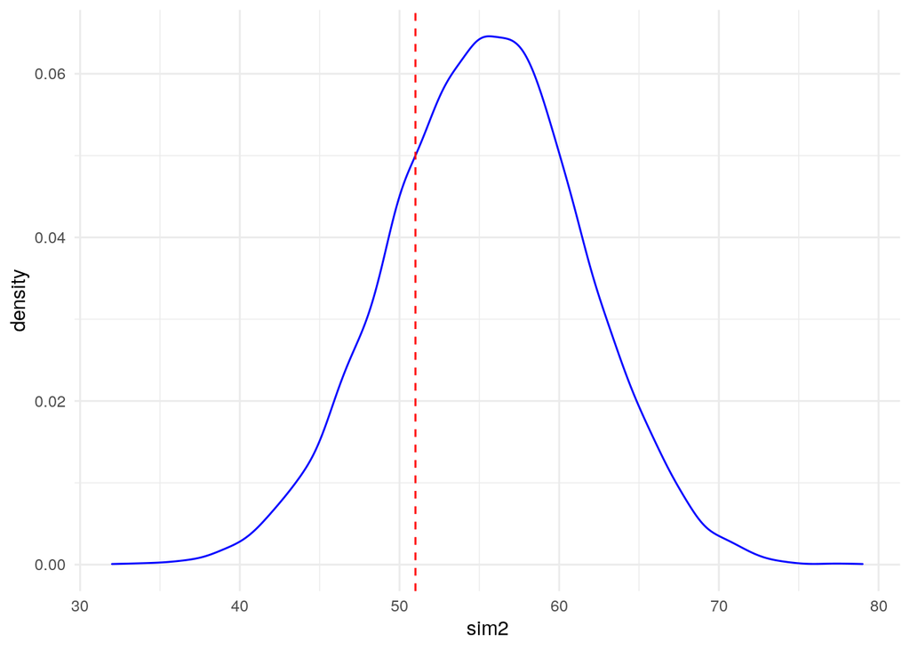

```r
sim2 <- rbinom(1e4, 100, prob = samples)

ggplot() +
  geom_density(aes(x = sim2), color = "blue") +
  geom_vline(xintercept = sum(birth1), color = "red", linetype = "dashed") +
  theme_minimal()
```

The model overestimates the likely proportion of first born boys.

### 3H5

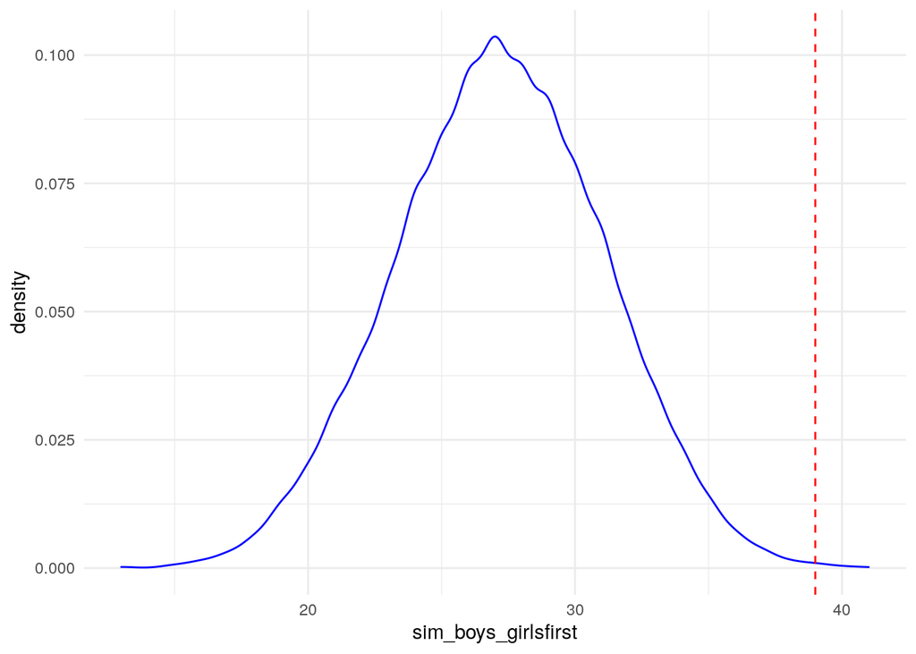

```r
# first born girls
girls_first <- length(birth1) - sum(birth1)

# simulate second born boys based on first born girls
sim_boys_girlsfirst <- rbinom(1e4, girls_first, prob = samples)

# actual second born boys following first born girls
boys_second <- sum(birth2[which(birth1 == 0)])

ggplot() +
  geom_density(aes(x = sim_boys_girlsfirst), color = "blue") +
  geom_vline(xintercept = boys_second, color = "red", linetype = "dashed") +
  theme_minimal()
```

The model expects a smaller number of boys as second borns after girls compared to the actual number, which implies that second births may not be independent of first births.

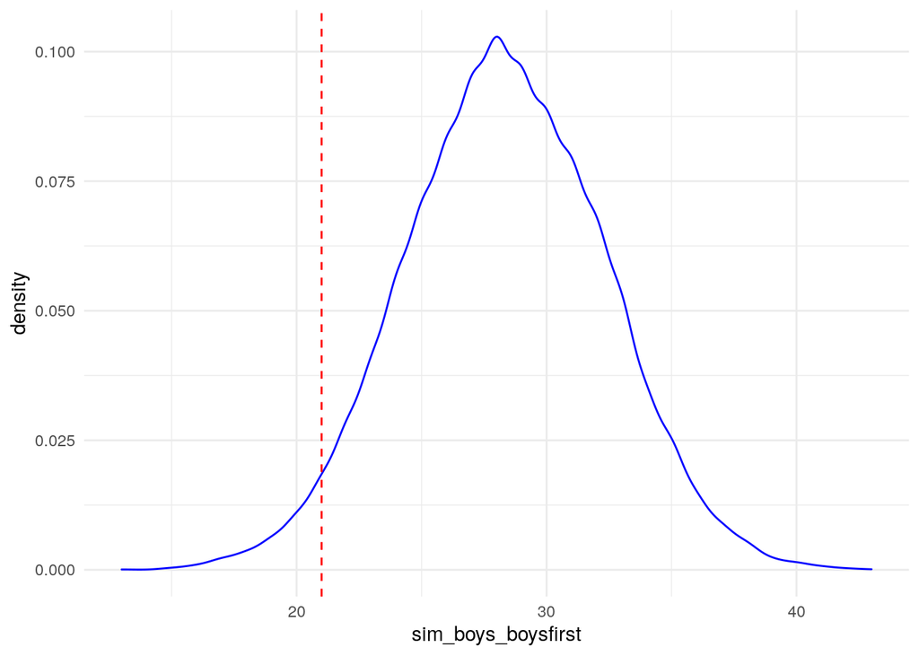

```r
# first born boys
boys_first <- sum(birth1)

# simulate second born boys based on first born boys
sim_boys_boysfirst <- rbinom(1e4, boys_first, prob = samples)

# actual second born boys following first born boys
boys_second <- sum(birth2[which(birth1 == 1)])

ggplot() +
  geom_density(aes(x = sim_boys_boysfirst), color = "blue") +
  geom_vline(xintercept = boys_second, color = "red", linetype = "dashed") +
  theme_minimal()
```

It seems that the gender of the first birth has an influence on the gender of the second birth. So we have tried to apply a model based on a sample of 200 independent births to a situation where the births are not actually independent.